# Moving beyond linearity – fitting a sine function

Let us work with a noisy trigonometric **sine** function. It is clearly non-linear, and we will attempt to fit it using models of varying complexity. In the beginning, we will assess how well a linear model performs. Then, we will propose a more suitable alternative model. Before you run the script, take a moment to think about the best model yourself.

## Data generation

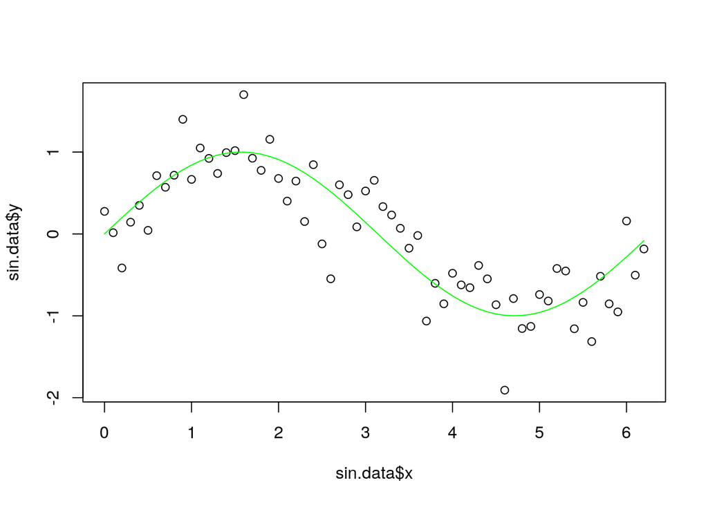

```r
x <- seq(0, pi * 2, 0.1)
#y <- sin(x)
y <- sin(x) + rnorm(n = length(x), mean = 0, sd = sd(sin(x) / 2))
sin.data <- data.frame(y,x)
# independent dataset for later testing
sin.test <- data.frame(x=seq(0, pi * 2, 0.1),y=sin(x) + rnorm(n = length(x), mean = 0, sd = sd(sin(x) / 2)))
plot(sin.data$x,sin.data$y)
lines(sin.data$x,sin(sin.data$x),col="green")
```

## How far a linear model can go?

```r
lm.sin <- lm(y ~ x, data = sin.data) # learn the linear model
lm.sin.pred <- predict(lm.sin, interval="confidence") # make predictions at testing points
summary(lm.sin) # the model works somehow, explains more than 40% of the variance, much better than averaging
```

```
##
## Call:
## lm(formula = y ~ x, data = sin.data)
##
## Residuals:
##      Min       1Q   Median       3Q      Max
## -1.44095 -0.34255 -0.00765  0.39791  1.26797
##
## Coefficients:
##             Estimate Std. Error t value Pr(>|t|)
## (Intercept)  0.91395    0.13556   6.742 6.42e-09 ***
## x           -0.30023    0.03772  -7.960 5.16e-11 ***
## ---
## Signif. codes:  0 '***' 0.001 '**' 0.01 '*' 0.05 '.' 0.1 ' ' 1
##
## Residual standard error: 0.5444 on 61 degrees of freedom
## Multiple R-squared:  0.5095, Adjusted R-squared:  0.5014
## F-statistic: 63.36 on 1 and 61 DF,  p-value: 5.159e-11
```

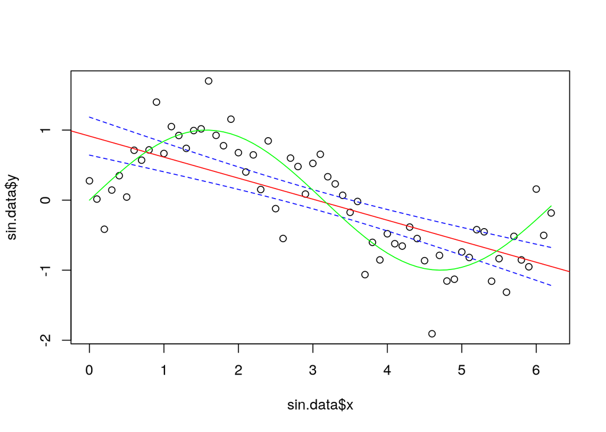

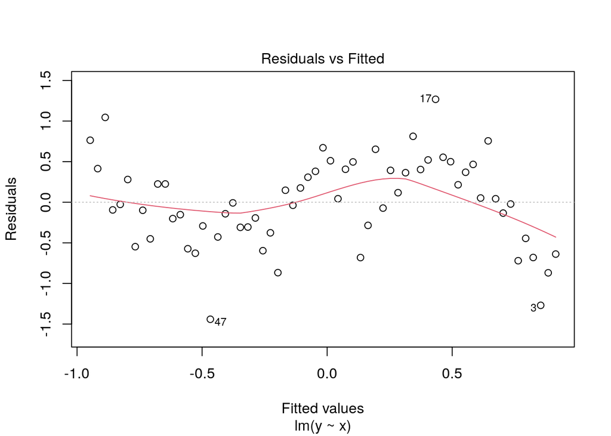

The **linear model** underfits the sine wave. It is unable to capture the relationship between the dependent and independent variable, it has a high error rate both on training as well as testing data (0.5357 and 0.6265, respectively). For one sine period, the linear model overcomes the **zero model** (0.765 and 0.8899, respectively), explains more than 40% of variance in the data, but we definitely need a more complex model. The cubic polynomial could be the first choice, its S shape with two inflection points resembles sine, although it will never fit the sine function perfectly for shape differences.

Before moving to nonlinear models, we demonstrate that lm() and gam() produce essentially the same results for models with closed-form solutions. Although the underlying algorithms differ (OLS vs. backfitting), any differences are negligible for simple linear tasks. The main difference for us would be that **generalized additive models (GAMs)** also allow for smooth terms, such as smoothing splines or local regression, which do not have closed-form solutions.

```r
gam.lin<-gam(y~x,data=sin.data) # simple gam, matches lm
summary(gam.lin)
```

```
##
## Call: gam(formula = y ~ x, data = sin.data)
## Deviance Residuals:
##       Min        1Q    Median        3Q       Max
## -1.440954 -0.342550 -0.007655  0.397911  1.267974
##
## (Dispersion Parameter for gaussian family taken to be 0.2964)
##
##     Null Deviance: 36.8555 on 62 degrees of freedom
## Residual Deviance: 18.0783 on 61 degrees of freedom
## AIC: 106.1358
##
## Number of Local Scoring Iterations: 2
##
## Anova for Parametric Effects
##           Df Sum Sq Mean Sq F value    Pr(>F)
## x          1 18.777 18.7772  63.358 5.159e-11 ***
## Residuals 61 18.078  0.2964
## ---
## Signif. codes:  0 '***' 0.001 '**' 0.01 '*' 0.05 '.' 0.1 ' ' 1
```

```r
coefficients(gam.lin) # the same as in lm.sin
```

```
## (Intercept)           x
##   0.9139534  -0.3002270
```

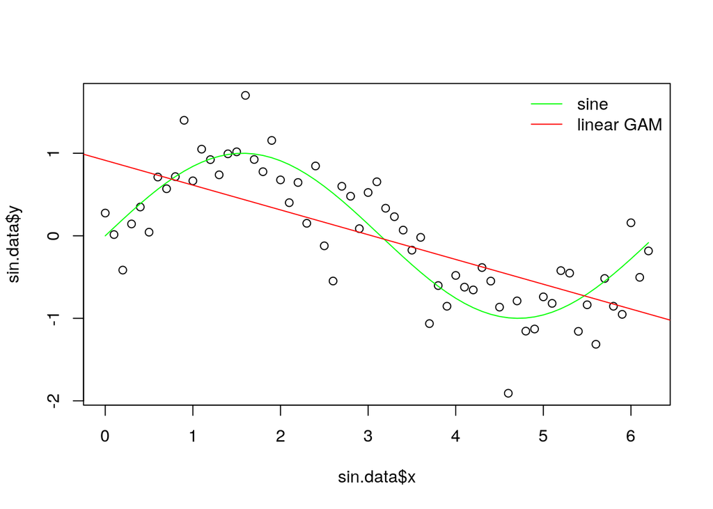

## Non-linear models

### Polynomial regression

We will begin with polynomial models, and then proceed to splines, exploring the optimal parametrization for each model type.

```r
lm.sin.cub <- lm(y ~ poly(x,3), data = sin.data) # learn the cubic polynomial model
lm.sin.pred <- predict(lm.sin.cub, interval="confidence") # make predictions at testing points
summary(lm.sin.cub) # the model works even better, explains nearly 80% of the variance, much better than linear model
```

```
##
## Call:
## lm(formula = y ~ poly(x, 3), data = sin.data)
##
## Residuals:
##      Min       1Q   Median       3Q      Max
## -1.01974 -0.17736  0.02781  0.22082  0.78301
##
## Coefficients:
##             Estimate Std. Error t value Pr(>|t|)
## (Intercept) -0.01675    0.04707  -0.356    0.723
## poly(x, 3)1 -4.33326    0.37359 -11.599  < 2e-16 ***
## poly(x, 3)2 -0.70787    0.37359  -1.895    0.063 .
## poly(x, 3)3  3.05659    0.37359   8.182  2.7e-11 ***
## ---
## Signif. codes:  0 '***' 0.001 '**' 0.01 '*' 0.05 '.' 0.1 ' ' 1
##
## Residual standard error: 0.3736 on 59 degrees of freedom
## Multiple R-squared:  0.7766, Adjusted R-squared:  0.7652
## F-statistic: 68.36 on 3 and 59 DF,  p-value: < 2.2e-16
```

```r
anova(lm.sin,lm(y ~ poly(x,2), data = sin.data),lm.sin.cub,lm(y ~ poly(x,4), data = sin.data),lm(y ~ poly(x,5), data = sin.data),lm(y ~ poly(x,6), data = sin.data),lm(y ~ poly(x,7), data = sin.data))
```

|  | Res.Df | RSS | Df | Sum of Sq | F | Pr(>F) |
| --- | --- | --- | --- | --- | --- | --- |
| 1 | 61 | 18.078349 | NA | NA | NA | NA |
| 2 | 60 | 17.577262 | 1 | 5.010868e-01 | 3.500598e+00 | 6.667017e-02 |
| 3 | 59 | 8.234509 | 1 | 9.342753e+00 | 6.526857e+01 | 6.487720e-11 |
| 4 | 58 | 8.234494 | 1 | 1.504777e-05 | 1.051239e-04 | 9.918565e-01 |
| 5 | 57 | 8.234222 | 1 | 2.714449e-04 | 1.896317e-03 | 9.654234e-01 |
| 6 | 56 | 8.184726 | 1 | 4.949598e-02 | 3.457794e-01 | 5.589190e-01 |
| 7 | 55 | 7.872877 | 1 | 3.118491e-01 | 2.178581e+00 | 1.456460e-01 |

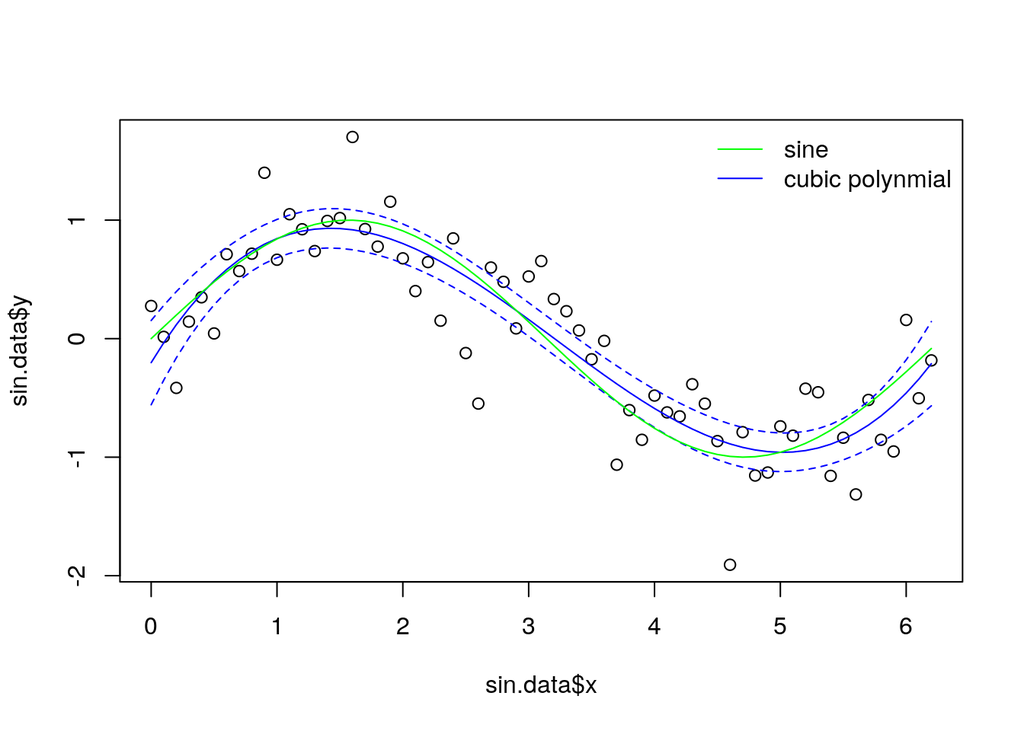

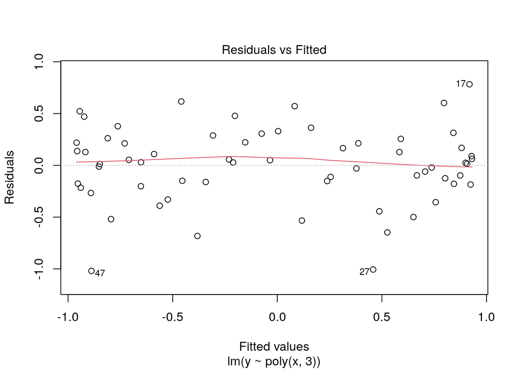

### Splines

In order to reach a better fit, we will demonstrate the application of splines. Let us start with the linear spline. The obvious choice is to work with two knots at $\pi/2$ and $3\pi/2$.

```r
gam.lins<-gam(y~bs(x,degree=1,knots=c(pi/2,3*pi/2)),data=sin.data) # gam with a linear spline with two knots
summary(gam.lins)
```

```
##
## Call: gam(formula = y ~ bs(x, degree = 1, knots = c(pi/2, 3 * pi/2)),
##     data = sin.data)
## Deviance Residuals:
##      Min       1Q   Median       3Q      Max
## -0.96572 -0.16778  0.04443  0.25613  0.73525
##
## (Dispersion Parameter for gaussian family taken to be 0.1355)
##
##     Null Deviance: 36.8555 on 62 degrees of freedom
## Residual Deviance: 7.9934 on 59 degrees of freedom
## AIC: 58.7218
##
## Number of Local Scoring Iterations: 2
##
## Anova for Parametric Effects
##                                              Df  Sum Sq Mean Sq F value
## bs(x, degree = 1, knots = c(pi/2, 3 * pi/2))  3 28.8621  9.6207  71.011
## Residuals                                    59  7.9934  0.1355
##                                                 Pr(>F)
## bs(x, degree = 1, knots = c(pi/2, 3 * pi/2)) < 2.2e-16 ***
## Residuals
## ---
## Signif. codes:  0 '***' 0.001 '**' 0.01 '*' 0.05 '.' 0.1 ' ' 1
```

```r
coefficients(gam.lins)
```

```
##                                   (Intercept)
##                                    0.01654329
## bs(x, degree = 1, knots = c(pi/2, 3 * pi/2))1
##                                    1.13099080
## bs(x, degree = 1, knots = c(pi/2, 3 * pi/2))2
##                                   -1.09668078
## bs(x, degree = 1, knots = c(pi/2, 3 * pi/2))3
##                                   -0.42246818
```

```r
gam.lins.pred <- predict(gam.lins, se.fit=T) # make predictions at testing points
```

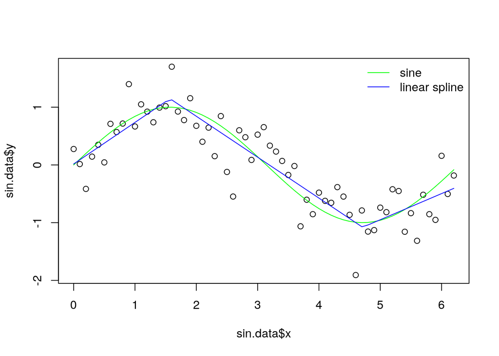

**Linear splines** with a small number of knots provide a rough piecewise-linear approximation of a sine wave. They are simple and interpretable but have limited accuracy, especially for functions with strong curvature like sine. Note, that we used domain knowledge to set the knots. In practice, the true function is most often not known and the knots have to be set suboptimally.

The **quadratic spline** with one knot at $\pi$ is the simplest choice with the desired S shape with two inflection points, we will also play with the cubic spline and a large-degree spline.

```r
gam.quad<-gam(y~bs(x,degree=2,knots=c(pi)),data=sin.data) # gam with a quadratic spline with one knot
gam.quad.pred <- predict(gam.quad, se.fit=T) # make predictions at testing points
summary(gam.quad)
```

```
##
## Call: gam(formula = y ~ bs(x, degree = 2, knots = c(pi)), data = sin.data)
## Deviance Residuals:
##      Min       1Q   Median       3Q      Max
## -1.09300 -0.18870  0.07048  0.21668  0.80521
##
## (Dispersion Parameter for gaussian family taken to be 0.1477)
##
##     Null Deviance: 36.8555 on 62 degrees of freedom
## Residual Deviance: 8.7126 on 59 degrees of freedom
## AIC: 64.1495
##
## Number of Local Scoring Iterations: 2
##
## Anova for Parametric Effects
##                                  Df  Sum Sq Mean Sq F value    Pr(>F)
## bs(x, degree = 2, knots = c(pi))  3 28.1429  9.3810  63.526 < 2.2e-16 ***
## Residuals                        59  8.7126  0.1477
## ---
## Signif. codes:  0 '***' 0.001 '**' 0.01 '*' 0.05 '.' 0.1 ' ' 1
```

```r
coefficients(gam.quad)
```

```
##                       (Intercept) bs(x, degree = 2, knots = c(pi))1
##                       -0.04083498                        1.82589642
## bs(x, degree = 2, knots = c(pi))2 bs(x, degree = 2, knots = c(pi))3
##                       -1.59072926                       -0.31231457
```